# R Markdown

MD

2026-03-09

# Induktivní (vs. deduktivní) úsudky

- logické úsudky

> Jestliže je Bohouš v Bratrstvu, tak nemá rád Rychlé šípy.

> Bohouš je v Bratrstvu.

> $\models$ Bohouš nemá rád Rychlé šípy.
- chybný úsudek:

> Jestliže je Bohouš v Bratrstvu, tak nemá rád Rychlé šípy.

> Bohouš není v Bratrstvu.

> $\not\models$ Bohouš má rád Rychlé šípy.
- deduktivní platnost: lepší spojení Pythonu a knihoven (R lepší pro induktivní úsudky)

```r
library(reticulate)
# py_install("truth-table-generator")
```

# Python + TTG

## Modus ponens

> Pokud je Miran Dušín Vont, tak nosí žlutý špendlík.

> Miran Dušín je Vont.

> Miran Dušín nosí žlutý špendlík.

```python
import ttg

print(ttg.Truths(['p', 'q'],['((p => q) and p) => q))']))
```

```
+-----+-----+---------------------------+
|  p  |  q  |  ((p => q) and p) => q))  |
|-----+-----+---------------------------|
|  1  |  1  |             1             |
|  1  |  0  |             1             |
|  0  |  1  |             1             |
|  0  |  0  |             1             |
+-----+-----+---------------------------+
```

# Monotonicita

> Pokud je Miran Dušín Vont, tak nosí žlutý špendlík.

> Miran Dušín je Vont.

> Prší

> Miran Dušín nosí žlutý špendlík.

```python
import ttg

print(ttg.Truths(['p', 'q', 'r'],['((p => q) and p and r) => q))']))
```

```
+-----+-----+-----+---------------------------------+
|  p  |  q  |  r  |  ((p => q) and p and r) => q))  |
|-----+-----+-----+---------------------------------|
|  1  |  1  |  1  |                1                |
|  1  |  1  |  0  |                1                |
|  1  |  0  |  1  |                1                |
|  1  |  0  |  0  |                1                |
|  0  |  1  |  1  |                1                |
|  0  |  1  |  0  |                1                |
|  0  |  0  |  1  |                1                |
|  0  |  0  |  0  |                1                |
+-----+-----+-----+---------------------------------+
```

- přidání další premisy nezruší deduktivní platnost

# Chybný úsudek

> Pokud je Miran Dušín Vont, tak nosí žlutý špendlík.

> Miran Dušín není Vont.

> Miran Dušín nenosí žlutý špendlík.

```python
import ttg

print(ttg.Truths(['p', 'q'],['((p => q) and ~ p) => ~ q))']))
```

```
+-----+-----+-------------------------------+
|  p  |  q  |  ((p => q) and ~ p) => ~ q))  |
|-----+-----+-------------------------------|
|  1  |  1  |               1               |
|  1  |  0  |               1               |
|  0  |  1  |               0               |
|  0  |  0  |               1               |
+-----+-----+-------------------------------+
```

## Induktivní úsudky jsou ne-monotonní

- obecně: induktivní úsudek je takový, kdy závěr plyne z premis(y) s větší pravděpodobností než jeho negace
- za pomocí podmíněné pravděpodobnosti: p(C | P) > p( ~ C | P)
- příklad:

|  | po | út | st | čt | pá | so | ne |
| --- | --- | --- | --- | --- | --- | --- | --- |
| horko | 1 | 0 | 1 | 1 | 1 | 0 | 0 |
| déšt | 1 | 1 | 1 | 1 | 0 | 0 | 0 |

- p(horko | déšt) = 3/4
- p( ~ horko | déšt) = 1/4
- takže následující argument je (v daném scénáři) induktivně platný

> Pršelo.

> Takže byl horký den
- simulace nenahodilého házení mincí (62 hodů ze 100 je T)
- klasicky frekventisticky

```r
# Performs an exact test of a simple null hypothesis about the probability of success in a Bernoulli experiment.
# first 62 cases are true (first 62 P are Q)
binom.test( x=62, n=100, p=.5 )
```

```
    Exact binomial test

data:  62 and 100
number of successes = 62, number of trials = 100, p-value = 0.02098
alternative hypothesis: true probability of success is not equal to 0.5
95 percent confidence interval:
 0.5174607 0.7152325
sample estimates:
probability of success
                  0.62
```

- ale po prvních 100 pouze 38 z druhých 100 P je Q

```r
binom.test( x=100, n=200, p=.5 )
```

```
    Exact binomial test

data:  100 and 200
number of successes = 100, number of trials = 200, p-value = 1
alternative hypothesis: true probability of success is not equal to 0.5
95 percent confidence interval:
 0.4286584 0.5713416
sample estimates:
probability of success
                   0.5
```

## Pravděpodobnosti součtů (2 kostky)

- ale po správném počtu pokusů (Zákon velkých čísel) se pravděpodobnost vzorku začne blížit pravděpodobnosti populace

```r
#vec1 <- sample(1:6, replace = TRUE)
#vec2 <- sample(1:6, replace = TRUE)

vec1 <- sample(1:6, 1000, replace=TRUE)
vec2 <- sample(1:6, 1000, replace=TRUE)

df <- cbind.data.frame(vec1, vec2)
str(df)
```

```
'data.frame':   1000 obs. of  2 variables:
 $ vec1: int  3 2 6 6 3 1 5 1 6 3 ...
 $ vec2: int  6 5 4 6 1 6 2 6 1 3 ...
```

```r
library(dplyr)

df <- df %>%
  mutate(sum = rowSums(select(.,vec1:vec2)))

str(df)
```

```
'data.frame':   1000 obs. of  3 variables:
 $ vec1: int  3 2 6 6 3 1 5 1 6 3 ...
 $ vec2: int  6 5 4 6 1 6 2 6 1 3 ...
 $ sum : num  9 7 10 12 4 7 7 7 7 6 ...
```

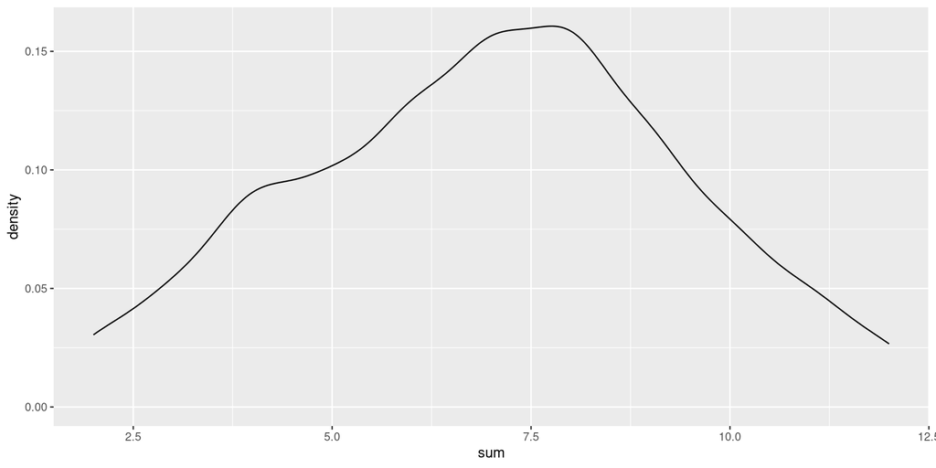

```r
library(ggplot2)
# Basic density
p <- ggplot(df, aes(x=sum)) +
  geom_density()
p
```

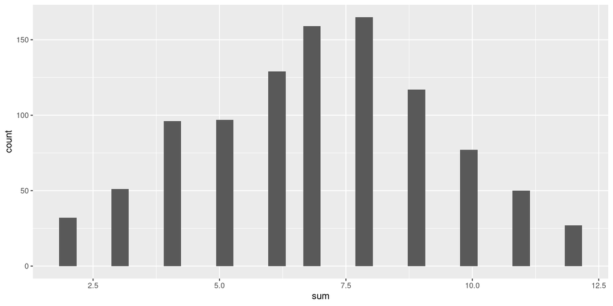

```r
q <- ggplot(df, aes(x=sum)) + geom_histogram()
q
```

- všechny předchozí příklady jsou napsány v nástavbě markdownu
- tu lze v RStudiu zpracovat buď jako quarto (tento dokument) nebo jako RMarkdown
- vytváření dynamických dokumentů (report), kde je možné vkládat kód (R, Python) a jeho výsledky

# R Markdown

- toto je příklad dokumentu v Quarto (nadstavba nad markdownem)
- Markdown je jednoduchý značkovací jazyk pro vytváření HTML, PDF a MS Word dokumentů
- jedna z adres: http://rmarkdown.rstudio.com.
- syntax je velmi jednoduchá: italika pomocí *výraz*
- bold: **výraz**
- odrážky pomocí: - - pod sebou
- více
  - zanořování
    - zanořování
- ale umožňuje TeX-zápis matematických formulí:
  $$\forall x[\mathbf{man}(x) \rightarrow \exists y[\mathbf{woman}(y) \wedge \mathbf{love}(x,y)]]$$
- vzniklo z:

```r
\forall x[\mathbf{man}(x) \rightarrow
\exists y[\mathbf{woman}(y) \wedge \mathbf{love}(x,y)]]
```

- asi nejpodstatnější: umožňuje interaktivní zanořování R kódu

```r
x <- seq(1, 100, by = 2)
y <- log(x)
y
```

```
 [1] 0.000000 1.098612 1.609438 1.945910 2.197225 2.397895 2.564949 2.708050
 [9] 2.833213 2.944439 3.044522 3.135494 3.218876 3.295837 3.367296 3.433987
[17] 3.496508 3.555348 3.610918 3.663562 3.713572 3.761200 3.806662 3.850148
[25] 3.891820 3.931826 3.970292 4.007333 4.043051 4.077537 4.110874 4.143135
[33] 4.174387 4.204693 4.234107 4.262680 4.290459 4.317488 4.343805 4.369448
[41] 4.394449 4.418841 4.442651 4.465908 4.488636 4.510860 4.532599 4.553877
[49] 4.574711 4.595120
```

```r
plot(x,y)
```

```r
str(x)
```

```
 num [1:50] 1 3 5 7 9 11 13 15 17 19 ...
```

[figure not shown]

```r
library(ggplot2)
df <- data.frame(x)
str(df)
```

```
'data.frame':   50 obs. of  1 variable:
 $ x: num  1 3 5 7 9 11 13 15 17 19 ...
```

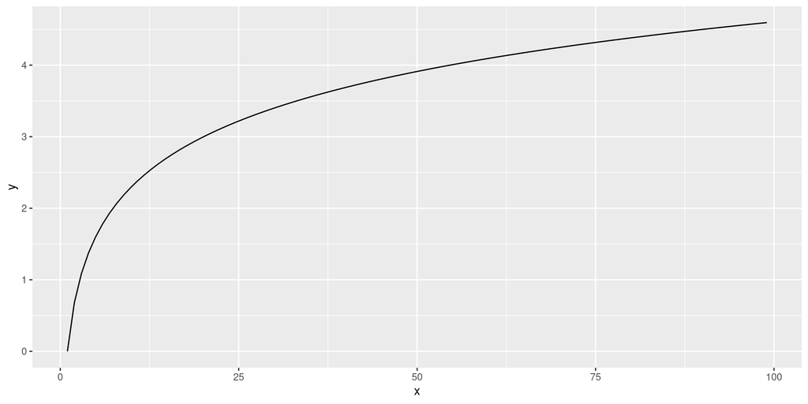

```r
ggplot(df,aes(x)) + stat_function(fun=function(x) log(x))
```

- chunk Pythonu
- lepší na algebru, logiku, …

```python
A = {1, 2, 1}
B = {1, 2}
A == B  # Python will say 'True'
```

```
True
```

```python
C = {3, 4}
A.union(C)
```

```
{1, 2, 3, 4}
```

```python
A.intersection(C)
```

```
set()
```

```python
len(A)  # tells you the size of A
```

```
2
```

```python
A <= B  # checks if A is a subset of B
```

```
True
```

```python
A < B   # checks if A is a proper subset of B
```

```
False
```

```python
{(a, b) for a in A for b in B} # Cartesian product AxB
```

```
{(1, 1), (1, 2), (2, 1), (2, 2)}
```

```python
emptyset = set()
A = {1, 2}
C = {3, 4}
A.intersection(C) == emptyset  # True
```

```
True
```

```python
D = {x ** 2 for x in range(3)}

print(D)
```

```
{0, 1, 4}
```

- pluralities

```python
#Python program to find powerset
from itertools import combinations
def print_powerset(string):
    for i in range(0,len(string)+1):
        for element in combinations(string,i):
            print(''.join(element))
string=['a','b','c']
print_powerset(string)
```

```
a
b
c
ab
ac
bc
abc
```

- pointwise sum

```python
# Python 3

list1 = ['a', 'b', 'c']
list2 = ['d', 'e', 'f']

assert len(list1) == len(list2)
result = [list1[i] + list2[i] for i in range(len(list1))]
print(result)
```

```
['ad', 'be', 'cf']
```

- obecné (i když subjetivní shrnutí)
1. R je nejlepší na statistiku (extrémní množství balíčků, knihovny jsou dobře známé i v lingvistické experimentální komunitě), případně induktivní úsudky
2. Python je lepší na algebru, klasickou deduktivní logiku, …
- Quarto umožňuje spojovat oba progrovací jazyky do jedněch slidů/reportu

# Knížky

https://bookdown.org/

- [R for Data Science: 28. Quarto](https://r4ds.hadley.nz/quarto)
- [R Markdown: The Definitive Guide](https://bookdown.org/yihui/rmarkdown/)
- [case studies](https://bookdown.org/yihui/rmarkdown/basics-examples.html#airbnbs-knowledge-repository)
- Quarto i Rmarkdown umožňují export do html (slidy, report), pdf, docx, odt
- moje nejčastější použití: slidy a reporty

```r
---
title: "Habits"
author: John Doe
date: March 22, 2005
output: beamer_presentation
---

# In the morning

## Getting up

- Turn off alarm
- Get out of bed

 ...
---

## Going to sleep
...

---
```

# In the morning

## Getting up

- Turn off alarm
- Get out of bed

## Breakfast

- Eat eggs
- Drink coffee

# In the evening

## Dinner

- Eat spaghetti
- Drink wine

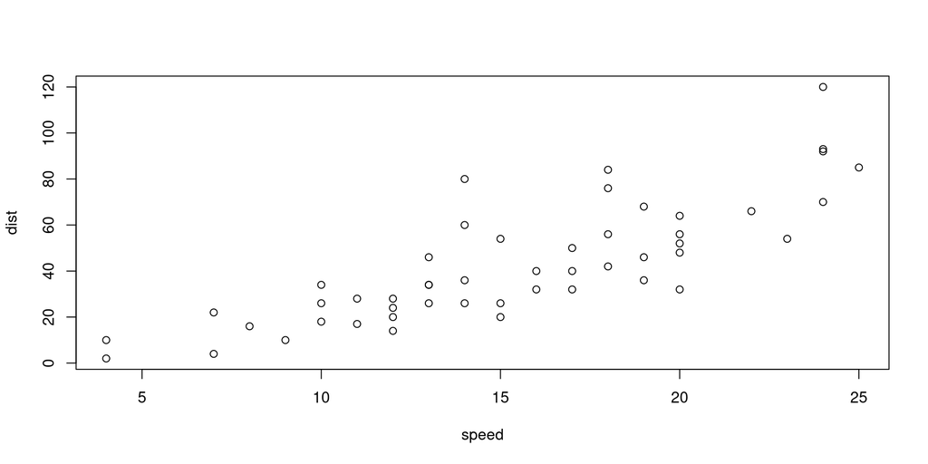

A scatterplot.

## Going to sleep

- Get in bed
- Count sheep
- rmarkdown: trochu příliš lehký
- rozšíření směrem k akademickému použití: TeXové citace:

```r
bibliography: biblio.bib
...
    includes:
      in_header: preamble.tex
    latex_engine: xelatex
    citation_package: natbib
```

- citace: @R-base
- vytvoří: R Core Team (2016)
- lingvistika: příklady
- expex makra:

One brown mouse jumped over the fence.

```r
\ex One brown mouse jumped over the fence.
\xe
```

- markdown je oficiální markovací jazyk na GitHubu
- dostanete se do [polar vault](https://www.youtube.com/watch?v=fzI9FNjXQ0o)
- ideální pro spolupráci:
- GitHub jako univerzálně použitelné úložiště pro experimenty, programování, etc.:
- největší plus: velmi propracovaný verzovací systém
- [editovatelný zdroják experimentu](https://github.com/MojmirDocekal/jan_2019_brn_vie)
- [samotný experiment na IBEXu](https://spellout.net/ibexexps/brno_vienna_experiments/feb_2020/experiment.html)
- [historie verzí](https://github.com/MojmirDocekal/jan_2019_brn_vie/commits/master/data_includes/example_data.js)
- práce s open-source knihami:
- fork knihy [Hands-On Programming with R](https://rstudio-education.github.io/hopr/)
- https://github.com/MojmirDocekal/hopr
- změněná kapitola bacics.rmd
- vlastní report: File -> New File -> R Markdown
- insert R chunk
- …
- rychlá kontrola: knit to html

# R a TeX

- [dizertace v Markdownu](https://github.com/matlipson/phd_thesis_markdown)
- mezikrok k Overleafu: [MUNI šablony na Overleafu](https://cs.overleaf.com/gallery/tagged/muni)
- první verze v markdownu, pak vyexportovat do TeXu
- případně Markdown v TeXu: https://www.overleaf.com/learn/latex/Articles/How_to_write_in_Markdown_on_Overleaf
- R Sweave: File -> New File -> R Sweave
- export do čistého TeXu
- propojení s Overleafem
- práce s verzemi v Overleafu
- [článek z FANSB](https://www.overleaf.com/project/5f626574068b1a0001c68b24)

# Domácí úloha

- v ČNK najít (např. ze jména) slovo: např. *čekat*:

[čekat](https://www.korpus.cz/slovo-v-kostce/search/cs/%C4%8Dekat)

- do dataframe hodit textové “Frekvence slova podle mluvčích (sociodemografické údaje)” – **relativní frekvence** (ipm)
- jednoduchý ggplot2 barplot graf
- zaslat výsledek reportu jako html
- obvyklé náležitosti: jméno, komentáře, …
- formulovat hypotézu: vyslovují muži dané slovo víc než ženy?
- jednoduchý xi-squared test

```r
x <- c("žena", "muž")
y <- c(250, 207)

df <- data.frame(x,y)
```

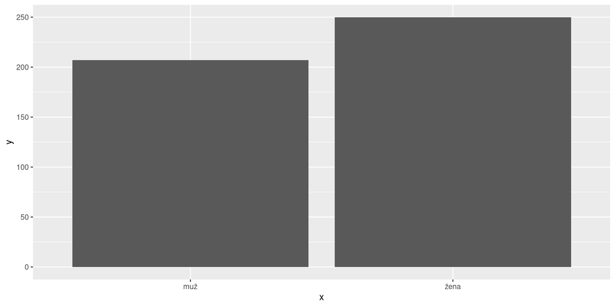

```r
library(ggplot2)

ggplot(aes(x = x, y = y), data = df) + geom_bar(stat="identity")
```

- inferenční statistika
- tzv. count data – nejobvyklejší metody Fisher’s exact test, chi-squared test, …
- nejjednodušší: chi-squared test

```r
chisq.test(df$y)
```

```
    Chi-squared test for given probabilities

data:  df$y
X-squared = 4.046, df = 1, p-value = 0.04428
```

```r
# the probability of men/women saying the word:

df$y[1]/sum(df$y)
```

```
[1] 0.547046
```

```r
df$y[2]/sum(df$y)
```

```
[1] 0.452954
```

- p-value říká, že data jsou rozdistribuována ne proporčně (tj. ne 50%, 50%)
- proporční data by vypadaly:

```r
occurences <- sum(df$y)
occurences
```

```
[1] 457
```

```r
occurences/2
```

```
[1] 228.5
```

```r
df2 <- df
df2$y <- c(occurences/2, occurences/2)

chisq.test(df2$y)
```

```
    Chi-squared test for given probabilities

data:  df2$y
X-squared = 0, df = 1, p-value = 1
```

- pro funkční slova to sedí: *být*

```r
df <- c(59807, 59135)

chisq.test(df)
```

```
    Chi-squared test for given probabilities

data:  df
X-squared = 3.7967, df = 1, p-value = 0.05135
```

# References

R Core Team. 2016. *R: A Language and Environment for Statistical Computing*. Vienna, Austria: R Foundation for Statistical Computing. https://www.R-project.org/.